# NASA ocean color data

This notebook demonstrates how we can access Ocean Color data from NASA.

The main repository for NASAs ocean color data is: https://oceandata.sci.gsfc.nasa.gov/opendap/

We will look at data from the MODIS-Aqua (MODIS-A) satellite, and in particular we will look at the level 3 product, which is data that has gone through the highest level of processing and nicely gridded.

NASA organizes data by year and year day. You can see this structure by clicking through the OpenDAP server. The file used in this example contains the mapped chlorophyll-a data for July 28 (year day 210), 2019.

### credit:

this lession is based on one from Tom Connolly: https://github.com/tompc35/oceanography-notebooks/blob/master/ocean_color_netcdf.ipynb

```python
# import statements

%matplotlib inline
import numpy as np
import matplotlib.pyplot as plt
import xarray as xr
```

# use `xr.open_dataset()` to access the data

the data for yearday 210 of 2019 is located at:

```
url = 'https://oceandata.sci.gsfc.nasa.gov:443/opendap/MODISA/L3SMI/2019/210/A2019210.L3m_DAY_CHL_chlor_a_4km.nc'
```

```python
url = 'https://oceandata.sci.gsfc.nasa.gov:443/opendap/MODISA/L3SMI/2019/210/A2019210.L3m_DAY_CHL_chlor_a_4km.nc'
data = xr.open_dataset(url)

data
```

```
<xarray.Dataset>
Dimensions:  (lat: 4320, lon: 8640, rgb: 3, eightbitcolor: 256)
Coordinates:
  * lat      (lat) float32 89.98 89.94 89.9 89.85 ... -89.85 -89.9 -89.94 -89.98
  * lon      (lon) float32 -180.0 -179.9 -179.9 -179.9 ... 179.9 179.9 180.0
Dimensions without coordinates: rgb, eightbitcolor
Data variables:
    palette  (rgb, eightbitcolor) int8 -109 0 108 -112 0 111 ... 105 0 0 0 0 0
    chlor_a  (lat, lon) float32 ...
Attributes: (12/64)
    _NCProperties:                     version=1|netcdflibversion=4.4.1.1|hdf...
    product_name:                      A2019210.L3m_DAY_CHL_chlor_a_4km.nc
    instrument:                        MODIS
    title:                             MODISA Level-3 Standard Mapped Image
    project:                           Ocean Biology Processing Group (NASA/G...
    platform:                          Aqua
    ...                                ...
    identifier_product_doi:            10.5067/AQUA/MODIS/L3M/CHL/2018
    keywords:                          Earth Science > Oceans > Ocean Chemist...
    keywords_vocabulary:               NASA Global Change Master Directory (G...
    data_bins:                         Attribute edlided: Unsupported attribu...
    data_minimum:                      0.008464555
    data_maximum:                      99.794235
```

# Subset the data

Again, let's just grab the mid-atlantic bight.

Note, that for some reason I don't understand, the `lat` `coords` are listed from high to low, so when you slice, you need to reverse the order, i.e. use `sel( lat=slice(41, 38))` *not* `sel( lat=slice( 38, 41)`. This is a mystery.

fill in the blanks to get a subset of the data that covers the MAB (the lat boundaries at 38 to 41 degrees, and lon boundaries are -76 to -71):

```
data_mab_nj = data.___( lat = ___, lon = ___)
```

```python
data_mab_nj = data.sel( lat=slice(41, 38), lon=slice(-76,-71))

data_mab_nj
```

```
<xarray.Dataset>
Dimensions:  (lat: 72, lon: 120, rgb: 3, eightbitcolor: 256)
Coordinates:
  * lat      (lat) float32 40.98 40.94 40.9 40.85 ... 38.15 38.1 38.06 38.02
  * lon      (lon) float32 -75.98 -75.94 -75.9 -75.85 ... -71.1 -71.06 -71.02
Dimensions without coordinates: rgb, eightbitcolor
Data variables:
    palette  (rgb, eightbitcolor) int8 -109 0 108 -112 0 111 ... 105 0 0 0 0 0
    chlor_a  (lat, lon) float32 nan nan nan nan ... 0.1958 0.1874 0.1862 0.1832
Attributes: (12/64)
    _NCProperties:                     version=1|netcdflibversion=4.4.1.1|hdf...
    product_name:                      A2019210.L3m_DAY_CHL_chlor_a_4km.nc
    instrument:                        MODIS
    title:                             MODISA Level-3 Standard Mapped Image
    project:                           Ocean Biology Processing Group (NASA/G...
    platform:                          Aqua
    ...                                ...
    identifier_product_doi:            10.5067/AQUA/MODIS/L3M/CHL/2018
    keywords:                          Earth Science > Oceans > Ocean Chemist...
    keywords_vocabulary:               NASA Global Change Master Directory (G...
    data_bins:                         Attribute edlided: Unsupported attribu...
    data_minimum:                      0.008464555
    data_maximum:                      99.794235
```

# plot the chlorophyll a

for the mid atlantic bight subset using the built-in xarray plotting routine. i.e. fill in the blanks, and remember we want to just plot the variable `chlor_a`:

```
data_mab_nj.___.___()
```

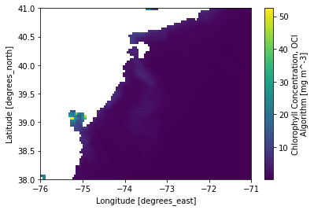

```python
data_mab_nj.chlor_a.plot()
```

# Chla should be plotted on a log scale

Let's make the same plot with matplotlib, and use `np.log10()` to plot the data on a logarythmic scale:

```
plt.pcolor( data_mab_nj.___, data_mab_nj.___, np.log10(data_mab_nj.___))
# add a colorbar below:
plt.___
```

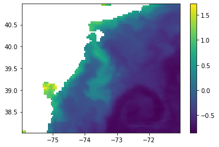

```python
plt.pcolor(data_mab_nj.lon, data_mab_nj.lat, np.log10(data_mab_nj.chlor_a))
plt.colorbar()
```